# Etude des liens entre variables temporelles

Analyse de données fonctionnelles avec les packages R {fda} et {MFPCA}

Stéphanie Bougeard, Gaspard Marquet, Virginie Allain, Claire Chauvin, Caroline Peltier (Inrae), Véronique Cariou (Oniris), Claude AI

2026-04-02

[figure not shown]

# 1 Packages

```r
library(xlsx)
library(reshape2)
library(kableExtra)
library(ggplot2)
library(gridExtra)
library(ggrepel)
library(pheatmap)
library(FactoMineR)
library(factoextra)
library(fda)
library(funData)
library(MFPCA)
```

# 2 Données temporelles

## 2.1 Données brutes

```r
data.amc <- xlsx:::read.xlsx("P:/Stephanie/1. Recherche/1. Publications-Présentations/98. Multibloc_Temporel/Programmes/Prog_R/Corrélation_Fonctionnelle/block_AMR_et_AMC.xlsx", sheetIndex = 2, header = TRUE)
data.amc$region <- as.factor(data.amc$region)
data.amc$annee  <- as.factor(data.amc$annee)
summary(data.amc[, 1:4])
```

```
##                      region       annee    log_AMC_EHPAD_C3G log_AMC_EHPAD_FQ
##  Auvergne-Rhone-Alpes   :13   2012   :12   Min.   :0.8755    Min.   :0.470
##  Bourgogne-Franche-Comte:13   2013   :12   1st Qu.:1.5651    1st Qu.:1.467
##  Bretagne               :13   2014   :12   Median :1.7204    Median :1.614
##  Centre-Val de Loire    :13   2015   :12   Mean   :1.7175    Mean   :1.618
##  Grand Est              :13   2016   :12   3rd Qu.:1.9113    3rd Qu.:1.862
##  Hauts-de-France        :13   2017   :12   Max.   :2.2303    Max.   :2.234
##  (Other)                :78   (Other):84   NA's   :1
```

## 2.2 Illustrations

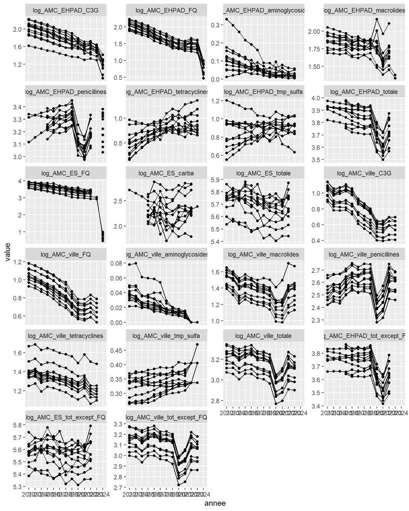

```r
data.amc.col <- melt(data.amc, id = c('region', 'annee'))

ggplot2:::ggplot(data.amc.col, aes(x = annee, y = value)) +
  geom_point() + geom_line(aes(group = region)) + geom_smooth(method = "loess") +
  facet_wrap(~ variable, scales = "free_y", ncol = 4)
```

## 2.3 Supression des données manquantes

- Suppression des années 2023 et 2024,
- Suppression des variables avec données manquantes restantes (P = 22 –> 18).
- !!! TEST si NA autorisées avec le package MFPCA (possibilité d’extrapolation avec les splines normalement) !!!

```r
data.amc.ssna1 <- droplevels(data.amc[!(data.amc$annee %in% c('2023', '2024')), ])
Nb.na.var      <- sapply(1:ncol(data.amc.ssna1), function(p) sum(is.na(data.amc.ssna1[, p])))
data.amc.ssna  <- data.amc.ssna1[, - which(Nb.na.var > 0)]
```

## 2.4 Paramètres

```r
Temps      <- levels(data.amc.ssna$annee)
NbTemps    <- length(Temps)
VarName    <- colnames(data.amc.ssna)[-c(1:2)]
NbVar      <- length(VarName)
Regions    <- levels(data.amc.ssna$region)
NbRegions  <- length(Regions)
my_palette <- colorRampPalette(c("blue", "grey", "red"))
```

## 2.5 Transformation des variables en matrices

- Vecteur d’observation = Région,
- Format (Temps $\times$ Région).

```r
data.amc.mat <- lapply(1:NbVar, function(p) as.matrix(reshape2:::dcast(data.amc.ssna, annee  ~ region, value.var = VarName[p])[, -1]))
```

# 3 Transformation en objets fonctionnels

## 3.1 Format ‘fd’

Objectif : Projection des variables temporelles dans une (même) base pour les transformer en objets fonctionnels.

- Chaque vecteur d’observation (= Région) est approximée par une fonction lissée,
- Pour cela, chaque vecteur d’observation (= Région) est projeté dans une même base (e.g., base de B-splines),
- La structure des fonctions prend en compte les liens entre $t_j$ et $t_{j+1}$ (temps non permutables).

Règles à appliquer pour la dimension de la base B-splines

- *norder = 3* signifie une fonction d’ordre 2, choix pour obtenir des courbes lissées,
- *nbasis = nb_nœuds_internes + norder*
- *nbasis* doit donc être plus grand que *norder* (= 3), mais plus petit que le nombre d’observations *N* (= 12)
- Pour obtenir des courbes lissées, il ne faut pas choisir trop de nœuds pour les fonctions splines.
- Ici, le choix sera *nbasis = 5*.

Création de la base

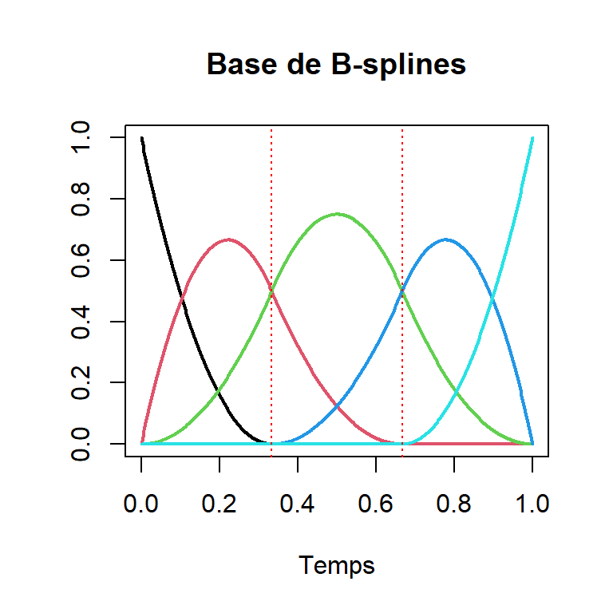

```r
Time.01      <- seq(0, 1, length.out = NbTemps)
Nb.Base      <- 5
spline.basis <- create.bspline.basis(rangeval = c(0, 1), nbasis = Nb.Base, norder = 3)
plot(spline.basis, lty = 1, lwd = 2, main = "Base de B-splines", xlab = 'Temps')
```

Projection des variables dans la base (format ‘fd’)

```r
data.amc.fd <- lapply(1:NbVar, function(p) smooth.basis(Time.01, data.amc.mat[[p]], spline.basis)$fd)
```

## 3.2 Format ‘fundata’

```r
data.amc.fun.uni  <- lapply(1:NbVar, function(p) funData(Time.01, t(data.amc.mat[[p]])))
data.amc.fun.mult <- multiFunData(data.amc.fun.uni)
```

# 4 Etude univariée

## 4.1 Corrélation fonctionnelle

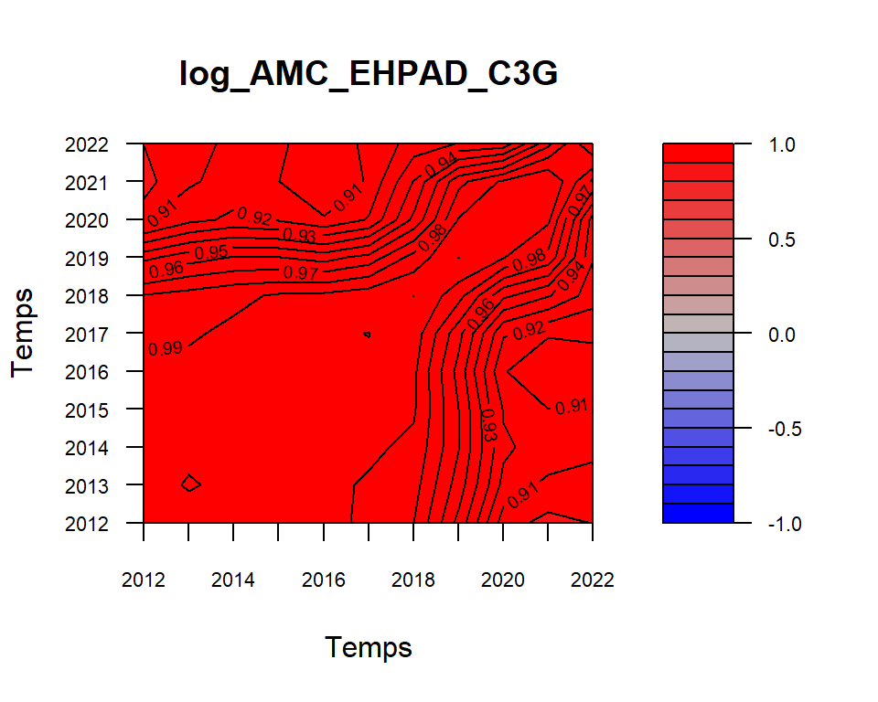

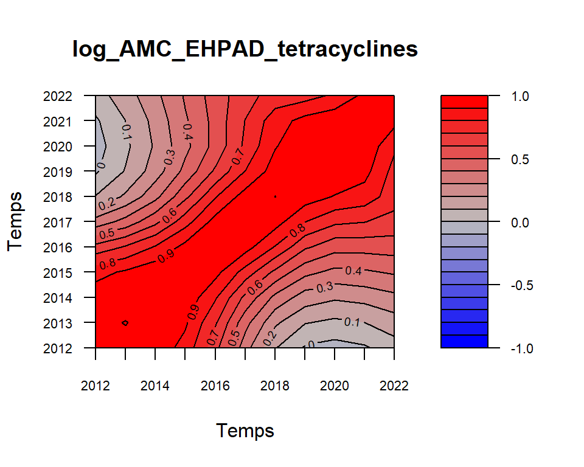

```r
cor.univ <- lapply(1:NbVar, function(p) cor.fd(Time.01, data.amc.fd[[p]]))

plot.cor.univ <- lapply(1:NbVar, function(p)
  filled.contour(Time.01, Time.01, cor.univ[[p]], color.palette = my_palette, zlim = c(-1, 1),
    plot.axes = {axis(1, at = Time.01, labels = Temps, cex.axis = 0.7)
                axis(2, at = Time.01, labels = Temps, cex.axis = 0.7)
                contour(Time.01, Time.01, cor.univ[[p]], add = TRUE, lwd = 1, cex.axis = 0.7)},
    key.axes = axis(4, cex.axis = 0.7), xlab = "Temps", ylab = "Temps", main = VarName[p]))
```

Synthèse

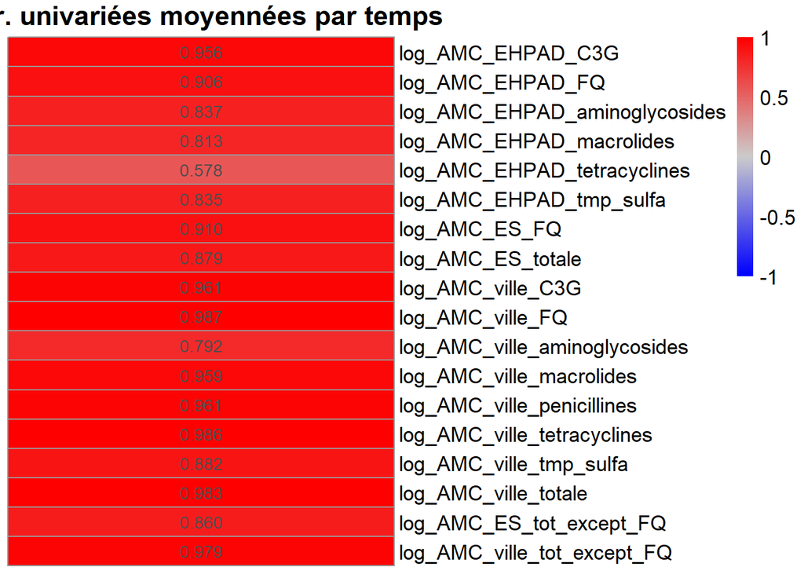

```r
cor.univ.na   <- cor.univ
cor.univ.mean <- matrix(NA, ncol = 1, nrow = NbVar)
for (p in 1:NbVar){
  diag(cor.univ.na[[p]]) <- NA
  cor.univ.mean[p]       <- round(mean(cor.univ.na[[p]], na.rm = TRUE), 3)
}
cor.univ.mean           <- matrix(cor.univ.mean, ncol = 1)
rownames(cor.univ.mean) <- VarName

pheatmap(cor.univ.mean,
         color = colorRampPalette(c("blue", "grey80", "red"))(100),
         breaks = seq(-1, 1, length.out = 101),
         display_numbers = TRUE,
         number_format = "%.3f",
         fontsize = 13,
         legend = TRUE,
         legend_breaks = c(-1, -0.5, 0, 0.5, 1),
         legend_labels = c("-1", "-0.5", "0", "0.5", "1"),
         cluster_rows = FALSE,
         cluster_cols = FALSE,
         main = "Cor. univariées moyennées par temps")
```

Interprétation

## 4.2 ACP fonctionnelle univariée

### 4.2.1 Principe

- Tout processus stochastique centré $x_i(t)$ de carré intégrable admet la décomposition de Karhunen-Loève suivante : $\hat{x}_i(t) = \mu_i(t) + \sum_{h=1}^H \hat{\rho}_{ih} \hat{\psi}_h(t)$ avec
  - $x_i(t)$ le vecteur relatif à chaque observation (= région) $i$,
  - $\rho_{ih}$ les scores pour une dimension donnée $h$ qui vérifient $E(\rho_{ih})=0$ et $E(\rho_{ih}^2)=\lambda_h$ avec $\lambda_h$ la valeur propre associée (= écart-type de chaque score $h$) ; elles ne dépendent pas du temps,
  - $\psi_h(t)$ sont les fonctions propres normalisées (= eigenfunctions/harmonic) de l’opérateur de covariance,
  - $\mu_i(t)=E(x_i(t))$ la fonction moyenne du processus,
  - $\mu_i(t) +/- \alpha.\sqrt{\lambda_h}.\hat{\psi}_h(t)$ la perturbation autour de la moyenne avec $\alpha$ un facteur d’échelle (généralement égal à 2).
- NB : On suppose un centrage par observation (= Région).

### 4.2.2 Sélection des dimensions à interpréter

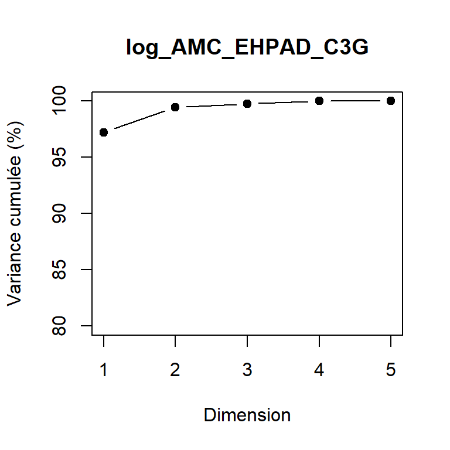

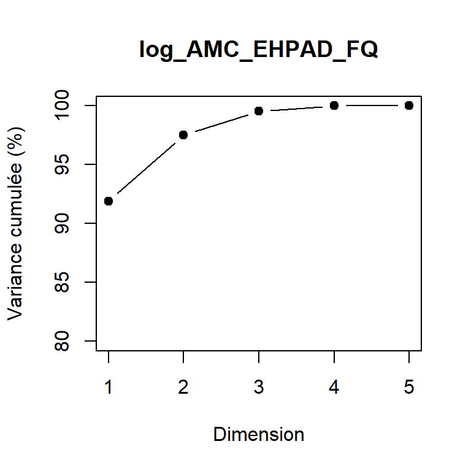

```r
fPCA.amc          <- lapply(1:NbVar, function(p) pca.fd(data.amc.fd[[p]], nharm = 5, centerfns = TRUE))
plot.var.acp.univ <- lapply(1:NbVar, function(p) plot(cumsum(fPCA.amc[[p]]$varprop)*100, type = 'b', pch = 19, main = VarName[p], xlab = "Dimension", ylab = "Variance cumulée (%)", ylim = c(80, 100)))
```

### 4.2.3 Perturbation autour de la moyenne

- **Objectif** : Interpréter les distinctions (fonctionnelles) des observations selon leur score sur composante $h$.
- **Graphe** : Représentation géométrique de la première direction principale dans l’espace $L^2$, centrée sur la moyenne empirique $\mu_i(t)$ et mise à l’échelle par l’écart-type des scores $\lambda_h$, conformément à la décomposition de Karhunen-Loève. Plus précisément, le graphe indique
  - La courbe moyenne (ligne centrale),
  - La perturbation positive (+), i.e., à quoi ressemble une observation avec un score élevé sur la composante $h$,
  - La perturbation négative (−), i.e., à quoi ressemble une observation avec un score faible sur la composante $h$.
  - Une variable dont les courbes perturbées sont quasi-confondues avec la moyenne ne contribue pas à cette composante.

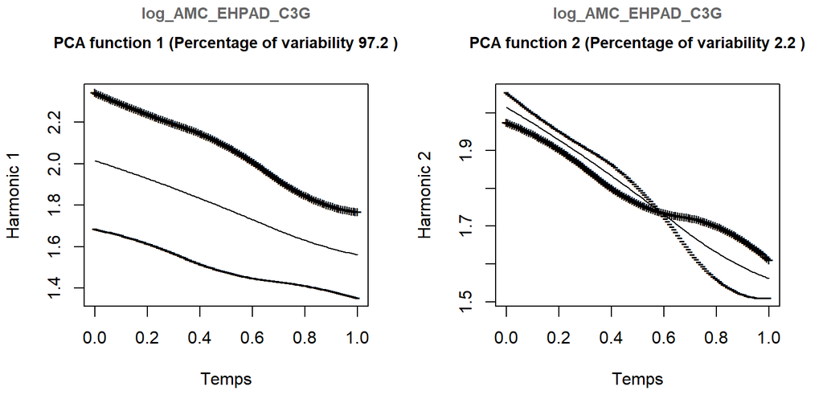

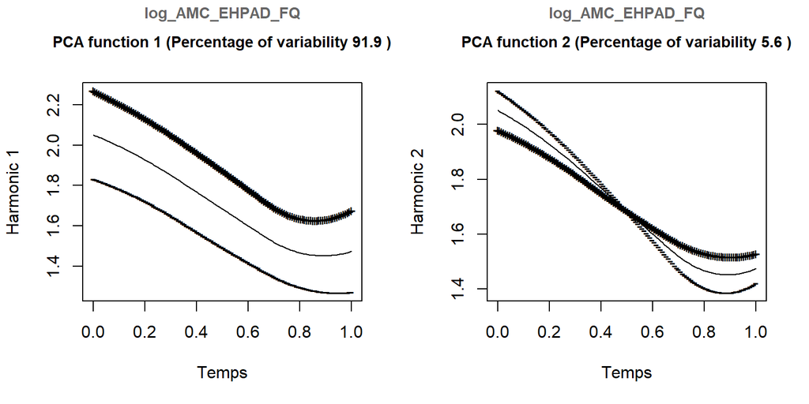

```r
for (p in 1 : NbVar){
  op <- par(mfrow = c(1, 2))
  plot.pca.fd(fPCA.amc[[p]], cex.main = 0.9, harm = 1, xlab = 'Temps')
  mtext(VarName[p], side = 3, line = 3, cex = 0.9, col = "gray40", font = 2)
  plot.pca.fd(fPCA.amc[[p]], cex.main = 0.9, harm = 2, xlab = 'Temps')
  mtext(VarName[p], side = 3, line = 3, cex = 0.9, col = "gray40", font = 2)
  par(op)
}
```

### 4.2.4 Scores

- Composantes principales fonctionnelles $(\rho_1, \dots, \rho_H)$ = Scores = Coordonnées des observations dans l’espace fonctionnel,
- Projection de chaque vecteur d’observation $i$ (= Région) sur la h-ième harmonique,
- Les scores sont des directions de plus grande variabilité dans l’espace fonctionnel.
- Ils ne dépendent pas du temps.
- Deux observations sont proches dans l’espace des scores ont des profils fonctionnels similaires pour la variable étudiée.

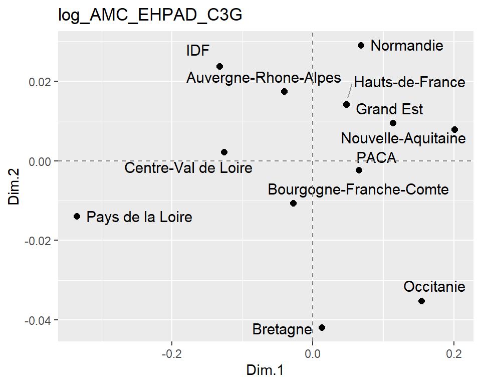

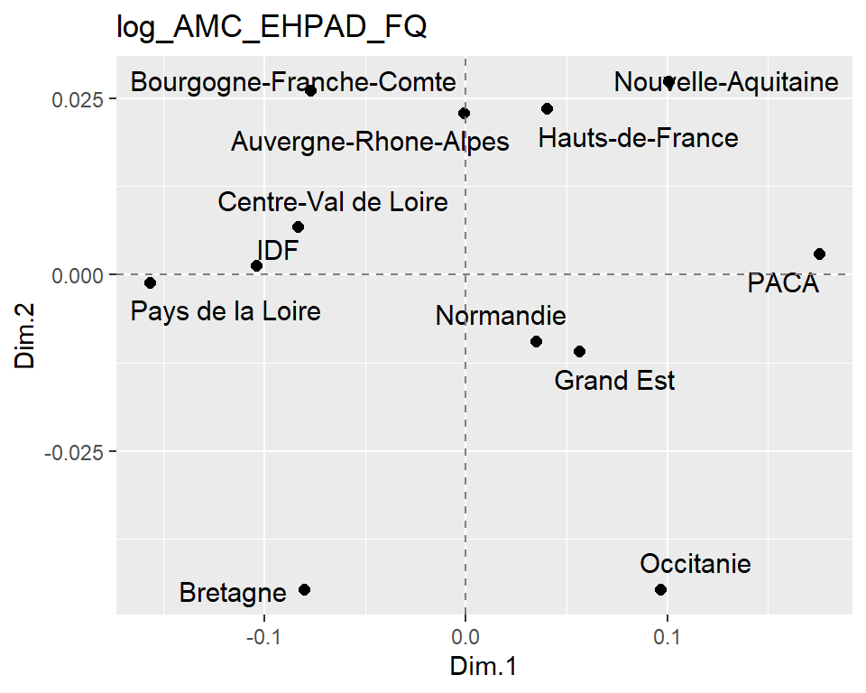

```r
scores <- list()
for (p in 1 : NbVar){
  scores[[p]]           <- fPCA.amc[[p]]$scores[, c(1:2)]
  colnames(scores[[p]]) <- paste('Dim', c(1:2), sep = '.')
  rownames(scores[[p]]) <- Regions

  print(ggplot2:::ggplot(scores[[p]], aes(x = Dim.1, y = Dim.2, label = rownames(scores[[p]]))) +
    geom_point(color = "black", size = 2) +
    geom_text_repel(size = 4, box.padding = 0.4, point.padding = 0.3, segment.color = "gray60", segment.size  = 0.4, max.overlaps  = Inf) +
  geom_hline(yintercept = 0, linetype = "dashed", color = "gray50") +
  geom_vline(xintercept = 0, linetype = "dashed", color = "gray50") +
 labs(x = "Dim.1", y = "Dim.2") + ggtitle(VarName[p]))
}
```

### 4.2.5 Interprétation

Cas de la variable ‘log_AMC_EHPAD_C3G’

### 4.2.6 Aller plus loin

- **Plan B** : Il est possible de récupérer les premières composantes/scores fonctionnelles de chaque variable (= meilleur résumé temporel en une dimension) puis de les utiliser pour appliquer des analyses statistiques standards.
- **Plan C** : Il est aussi possible de récupérer plusieurs composantes/scores fonctionnelles par variable et de appliquer des analyses statistiques 3-voies ‘NbObs $\times$ NbVar $\times$ NbDim’ (avec une meilleure prise en compte du temps et une meilleure capacité de synthèse qu’une analyse 3-voies sur les données brutes ‘NbObs $\times$ NbVar $\times$ NbTemps’).

```r
sum.var           <- sapply(1:NbVar, function(p) fPCA.amc[[p]]$scores[, 1, drop = F])
colnames(sum.var) <- VarName
rownames(sum.var) <- Regions
```

# 5 Etude bivariée

## 5.1 Corrélations fonctionnelles

- Corrélation (linéaire) calculée entre ces courbes (= fonctions)
- Si la corrélation est concentrée sur la diagonale, les variables sont corrélées aux mêmes temps.

```r
cor.bivar <- array(NA, dim = c(NbTemps, NbTemps, NbVar, NbVar))
for (p in 1 : NbVar){
  for (p1 in 1 : NbVar){
    cor.bivar[, , p, p1] <- cor.fd(Time.01, data.amc.fd[[p]], Time.01, data.amc.fd[[p1]])
  }
}
```

Exemples

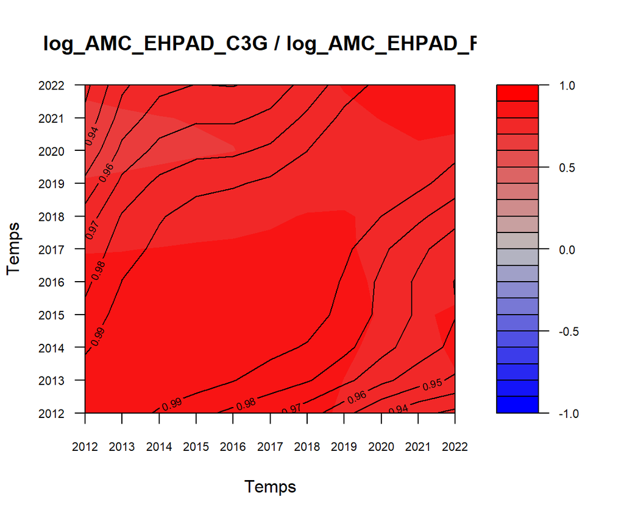

```r
filled.contour(Time.01, Time.01, cor.bivar[, , 1, 2],
    color.palette = my_palette, zlim = c(-1, 1),
    plot.axes = {axis(1, at = Time.01, labels = Temps, cex.axis = 0.7)
                axis(2, at = Time.01, labels = Temps, cex.axis = 0.7)
                contour(Time.01, Time.01, cor.univ[[p]], add = TRUE, lwd = 1, cex.axis = 0.7)},
    key.axes = axis(4, cex.axis = 0.7),
    xlab = "Temps", ylab = "Temps", main = paste(VarName[1], VarName[2], sep = ' / '))
```

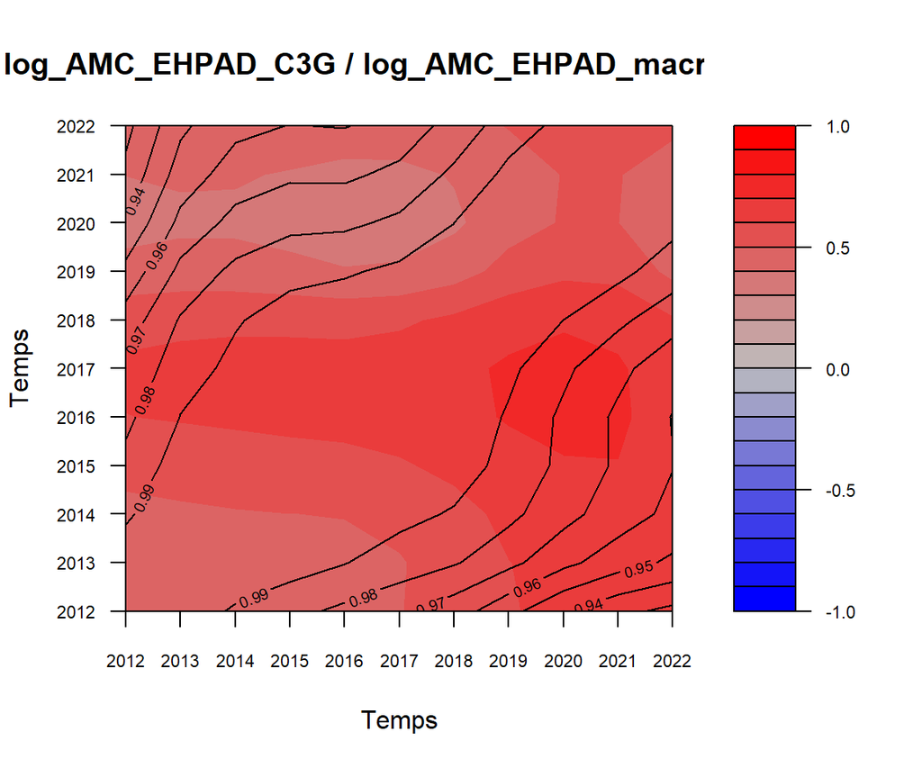

```r
filled.contour(Time.01, Time.01, cor.bivar[, , 1, 4],
    color.palette = my_palette, zlim = c(-1, 1),
    plot.axes = {axis(1, at = Time.01, labels = Temps, cex.axis = 0.7)
                axis(2, at = Time.01, labels = Temps, cex.axis = 0.7)
                contour(Time.01, Time.01, cor.univ[[p]], add = TRUE, lwd = 1, cex.axis = 0.7)},
    key.axes = axis(4, cex.axis = 0.7),
    xlab = "Temps", ylab = "Temps", main = paste(VarName[1], VarName[4], sep = ' / '))
```

## 5.2 Synthèse

### 5.2.1 Par les moyennes

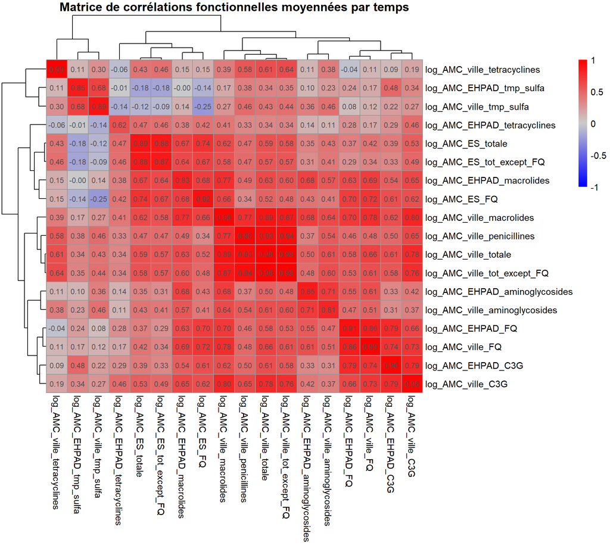

```r
cor.bivar.mean <- as.matrix(apply(cor.bivar, c(3, 4), FUN = mean, na.rm = TRUE))
colnames(cor.bivar.mean) <- rownames(cor.bivar.mean) <- VarName

pheatmap(cor.bivar.mean,
         color = colorRampPalette(c("blue", "grey80", "red"))(100),
         breaks = seq(-1, 1, length.out = 101),
         cluster_rows = TRUE,
         cluster_cols = TRUE,
         clustering_distance_rows = "euclidean",
         clustering_distance_cols = "euclidean",
         clustering_method = "ward.D2",
         display_numbers = TRUE,
         number_format = "%.2f",
         fontsize = 11,
         legend = TRUE,
         legend_breaks = c(-1, -0.5, 0, 0.5, 1),
         legend_labels = c("-1", "-0.5", "0", "0.5", "1"),
         main = "Matrice de corrélations fonctionnelles moyennées par temps")
```

### 5.2.2 Par les corrélations entre composantes fonctionnelles

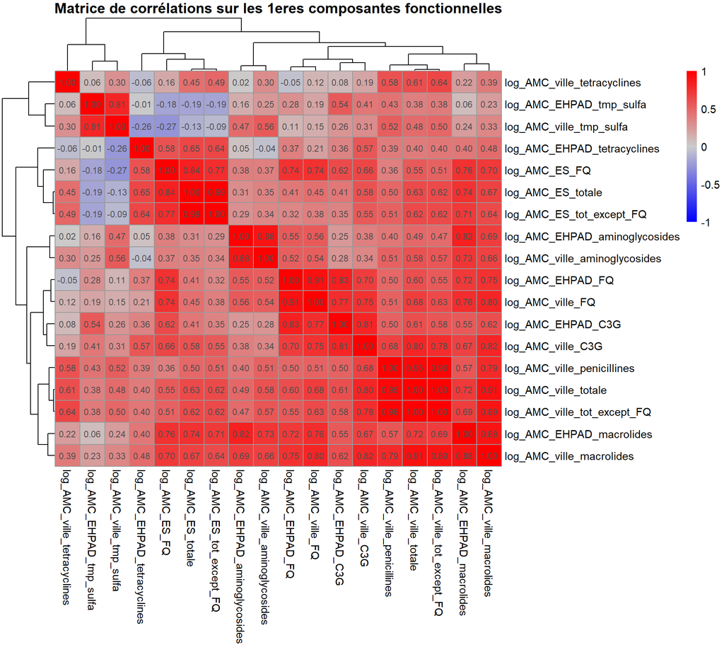

```r
pheatmap(cor(sum.var),
         color = colorRampPalette(c("blue", "grey80", "red"))(100),
         breaks = seq(-1, 1, length.out = 101),
         cluster_rows = TRUE,
         cluster_cols = TRUE,
         clustering_distance_rows = "euclidean",
         clustering_distance_cols = "euclidean",
         clustering_method = "ward.D2",
         display_numbers = TRUE,
         number_format = "%.2f",
         fontsize = 11,
         legend = TRUE,
         legend_breaks = c(-1, -0.5, 0, 0.5, 1),
         legend_labels = c("-1", "-0.5", "0", "0.5", "1"),
         main = "Matrice de corrélations sur les 1eres composantes fonctionnelles")
```

# 6 Etude multivariée

## 6.1 ACP ‘simpliste’

- Suppose l’indépendance des observations (ici ‘Régions $\times$ Temps’) qui n’est pas vérifiée.

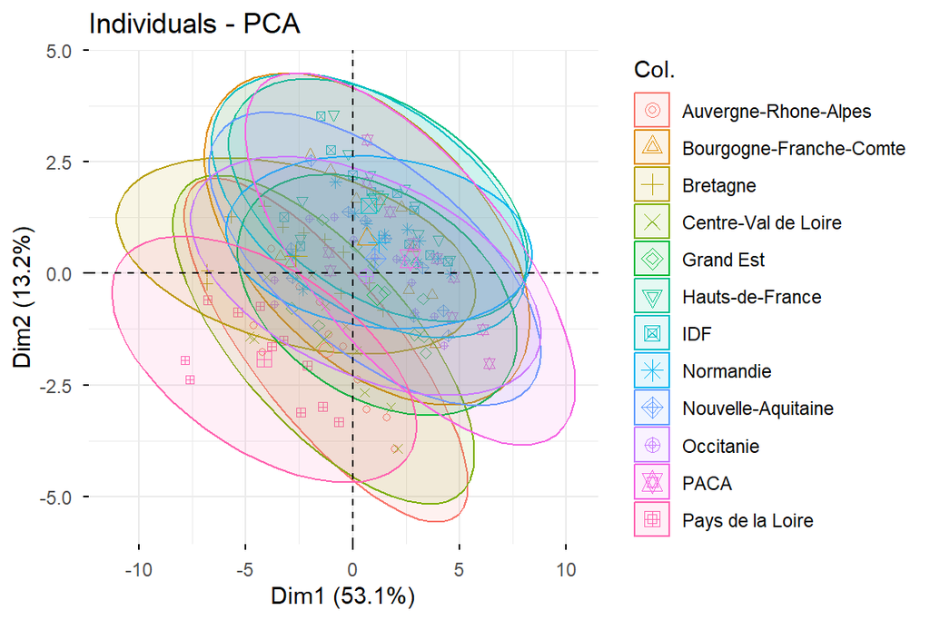

```r
res.pca <- PCA(data.amc.ssna, scale.unit = TRUE, ncp = 2, quali.sup = c(1, 2), graph = FALSE)
fviz_pca_ind(res.pca, addEllipses = TRUE, col.ind = data.amc.ssna$region, label = "none")
```

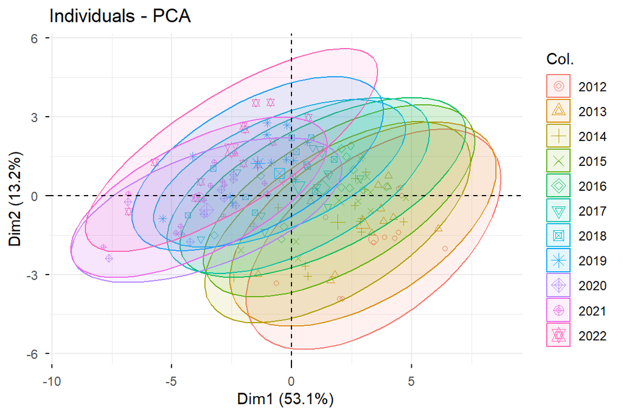

```r
fviz_pca_ind(res.pca, addEllipses = TRUE, col.ind = data.amc.ssna$annee, label = "none")
```

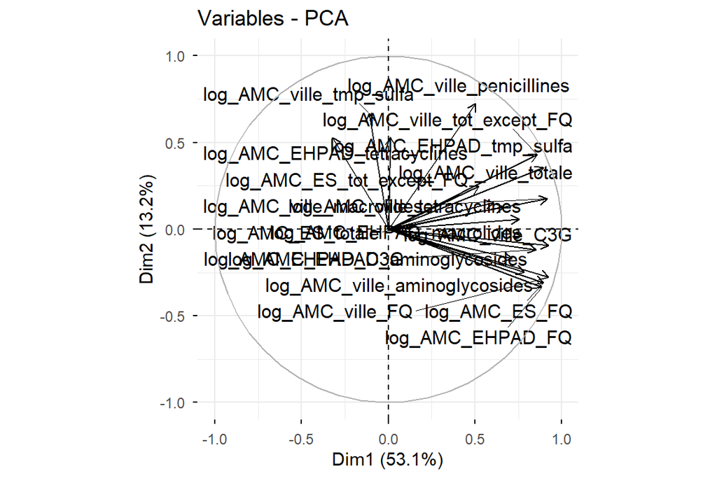

```r
fviz_pca_var(res.pca, col.var = "black", repel = TRUE)
```

## 6.2 ACP sur les 1eres composantes fonctionnelles

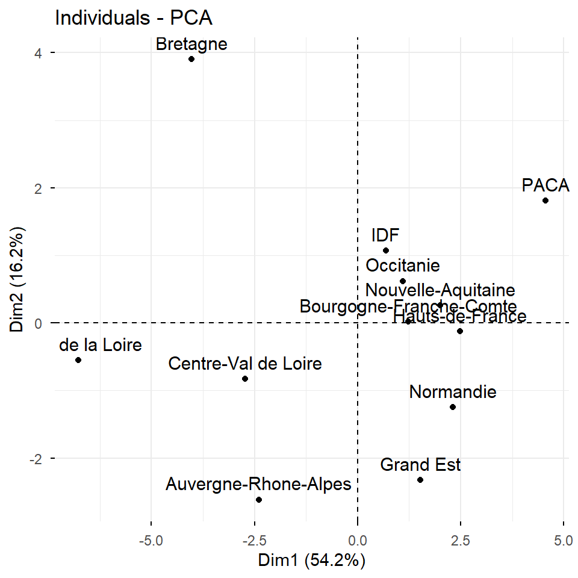

```r
res.pca1 <- PCA(sum.var, scale.unit = TRUE, ncp = 2, graph = FALSE)
fviz_pca_ind(res.pca1)
```

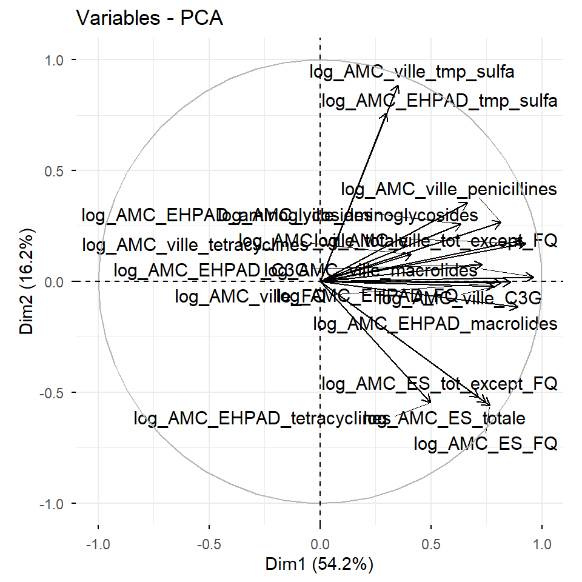

```r
fviz_pca_var(res.pca1, col.var = "black", repel = TRUE)
```

## 6.3 ACP fonctionnelle multivariée

### 6.3.1 Principe

- Pour chaque variable $p=(1, \dots, P)$, tout processus stochastique centré $x_{ip}(t)$ de carré intégrable admet la décomposition de Karhunen-Loève suivante : $\hat{x}_{ip}(t) = \mu_{ip}(t) + \sum_{h=1}^H \hat{\rho}_{ih} \hat{\psi}_{ph}(t)$ avec
  - $x_{ip}(t)$ le vecteur relatif à chaque observation (= région) $i$ et chaque variable $p$,
  - $\rho_{ih}$ les scores pour une dimension donnée $h$, qui vérifient $E(\rho_{ih})=0$ et $E(\rho_{ih}^2)=\lambda_h$ avec $\lambda_h$ la valeur propre associée (= écart-type de chaque score $h$); elles ne dépendent pas du temps ni des variables. En effet, les $P$ variables contribuent ensemble à construire les scores, pondérées par leur fonction propre respective $\psi_{ph}$,
  - $\psi_{ph}(t)$ sont des vecteurs de fonctions propres (= eigenfunctions/harmonic) $(\psi_{1h}(t), \dots, \psi_{Ph}(t))$ de l’opérateur de covariance (opérateur matriciel $P \times P$ de noyaux),
  - $\mu_{ip}(t)=E(x_{ip}(t))$ la fonction moyenne du processus,
  - $\mu_{ip}(t) +/- \alpha.\sqrt{\lambda_h}.\hat{\psi}_{ph}(t)$ la perturbation autour de la moyenne avec $\alpha$ un facteur d’échelle (généralement égal à 2).
- Illustration des corrélations fonctionnelles linéaires entre les variables (i.e., matrice bloc-diagonale)
- NB : On suppose un centrage par observation (= Région).

### 6.3.2 Sélection des dimensions à interpréter

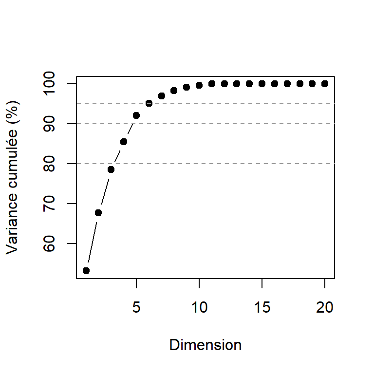

```r
res.mfpca2     <- MFPCA:::MFPCA(data.amc.fun.mult, M = 20, uniExpansions = rep(list(list(type = "splines1Dpen", k = 10)), NbVar))
propvar.mfpca2 <- as.vector(res.mfpca2$values/sum(res.mfpca2$values)*100)

plot(cumsum(propvar.mfpca2), type = "b", pch = 19, xlab = "Dimension", ylab = "Variance cumulée (%)")
abline(h = c(80, 90, 95), lty = 2, col = "gray60")
```

### 6.3.3 Contributions des variables

- La variance expliquée par la composante $h$ vaut $\lambda_h$.
- Elle se décompose pour chaque variable $p$ selon la norme $||\psi_{ph}(t)||^2$, en notant que $\sum_p ||\psi_{ph}(t)||^2=1$ quand la fonction est normalisée.
- Ces contributions permettent de n’interpréter que les variables importantes pour une composante donnée.

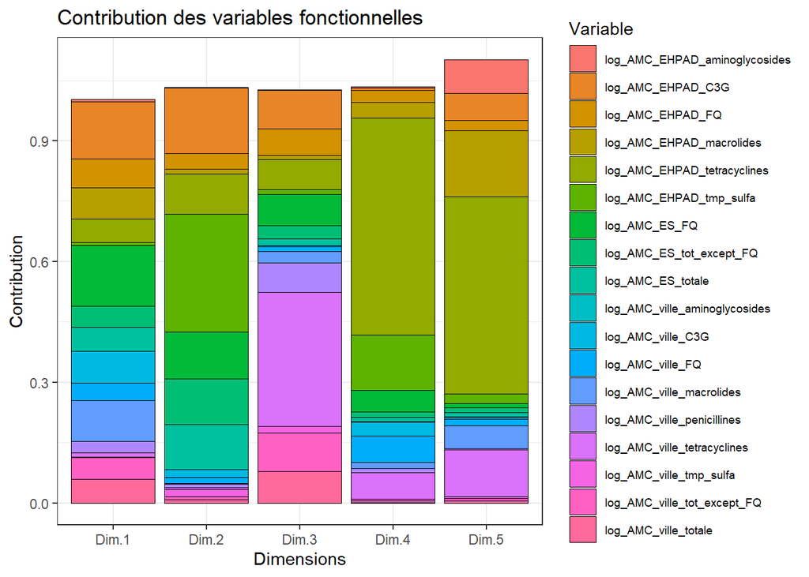

```r
dim.sel <- 5
contrib <- data.frame()
j       <- 1
for (p in 1 : NbVar){
  for(h in 1 : dim.sel){
    contrib[j, 'Variable']     <- VarName[p]
    contrib[j, 'Dim']          <- paste0("Dim.", h)
    contrib[j, 'Contribution'] <- sum(res.mfpca2$functions[[p]][h, ]@X^2) / length(res.mfpca2$functions[[p]][h, ]@X)
    j <- j + 1
  }
}
ggplot(contrib, aes(x = Dim, y = Contribution, fill = Variable)) + geom_col() + theme_bw() + labs(x = 'Dimensions', title = 'Contribution des variables fonctionnelles') + theme(legend.text = element_text(size = 7)) + geom_col(color = "black", linewidth = 0.3)
```

Sélection des variables à interpréter selon les dimensions

```r
contrib$Variable <- factor(contrib$Variable, levels = unique(contrib$Variable))
contrib.col <- as.matrix(reshape2:::acast(contrib, Variable  ~ Dim, value.var = "Contribution"))
varsel.dim  <- lapply(1:dim.sel, function(h) which(contrib.col[, h] > 0.1))
varsel.dim
```

```
## [[1]]
##        log_AMC_EHPAD_C3G            log_AMC_ES_FQ log_AMC_ville_macrolides
##                        1                        7                       12
##
## [[2]]
##        log_AMC_EHPAD_C3G  log_AMC_EHPAD_tmp_sulfa            log_AMC_ES_FQ
##                        1                        6                        7
##        log_AMC_ES_totale log_AMC_ES_tot_except_FQ
##                        8                       17
##
## [[3]]
## log_AMC_ville_tetracyclines
##                          14
##
## [[4]]
## log_AMC_EHPAD_tetracyclines     log_AMC_EHPAD_tmp_sulfa
##                           5                           6
##
## [[5]]
##    log_AMC_EHPAD_macrolides log_AMC_EHPAD_tetracyclines
##                           4                           5
## log_AMC_ville_tetracyclines
##                          14
```

### 6.3.4 Perturbation autour de la moyenne

- **Objectif** : Interpréter les distinctions (fonctionnelles) des observations selon leur score sur composante $h$.
- **Graphe** : Représentation géométrique de la première direction principale dans l’espace $L^2$, centrée sur la moyenne empirique $\mu_{ip}(t)$ et mise à l’échelle par l’écart-type des scores $\lambda_h$, conformément à la décomposition de Karhunen-Loève. Plus précisément, le graphe indique
  - La courbe moyenne de chaque variable $p$ (ligne centrale),
  - La perturbation positive (+), i.e., à quoi ressemble une observation avec un score élevé sur la composante $h$ pour la variable $p$,
  - La perturbation négative (−), i.e., à quoi ressemble une observation avec un score faible sur la composante $h$ pour la variable $p$.
  - Une variable dont les courbes perturbées sont quasi-confondues avec la moyenne ne contribue pas à cette composante.

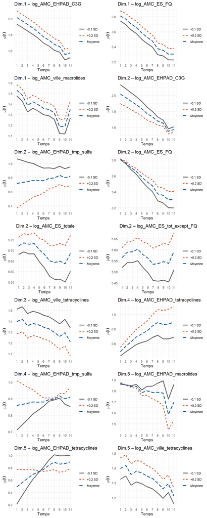

```r
plot_effect <- function(h, p) {
  mean.p   <- res.mfpca2$meanFunction[[p]]@X
  harm.hp  <- res.mfpca2$functions[[p]][h]@X

  df <- data.frame(t      = rep(c(1:NbTemps), 3),
                   valeur = c(mean.p, mean.p + 0.2 * harm.hp, mean.p - 0.2 * harm.hp),
                   profil = rep(c("Moyenne", "+0.2 SD", "−0.1 SD"), each = NbTemps))

  ggplot(df, aes(x = t, y = valeur, color = profil, linetype = profil)) +
    geom_line(linewidth = 1.2) +
    scale_color_manual(values = c("gray40", "#D85A30", "#185FA5")) +
    scale_x_continuous(breaks = c(1:NbTemps)) +
    labs(title = paste0("Dim.", h, " – ", VarName[p]), x = "Temps", y = expression(mu(t)), color = NULL, linetype = NULL) + theme_minimal()
}
plot.eigenf.dim1 <- lapply(varsel.dim[[1]], function(p) plot_effect(h = 1, p))
plot.eigenf.dim2 <- lapply(varsel.dim[[2]], function(p) plot_effect(h = 2, p))
plot.eigenf.dim3 <- lapply(varsel.dim[[3]], function(p) plot_effect(h = 3, p))
plot.eigenf.dim4 <- lapply(varsel.dim[[4]], function(p) plot_effect(h = 4, p))
plot.eigenf.dim5 <- lapply(varsel.dim[[5]], function(p) plot_effect(h = 5, p))
do.call(grid.arrange, c(plot.eigenf.dim1, plot.eigenf.dim2, plot.eigenf.dim3, plot.eigenf.dim4, plot.eigenf.dim5, ncol = 2))
```

### 6.3.5 Scores

- Composantes principales fonctionnelles $(\rho_1, \dots, \rho_H)$ = Scores = Coordonnées des observations dans l’espace fonctionnel,
- Projection de chaque vecteur d’observation $i$ (= Région) sur la h-ième harmonique,
- Les scores sont des directions de plus grande variabilité dans l’espace fonctionnel.
- Ils ne dépendent pas du temps.
- En ACP fonctionnelle multivariée, les scores sont une synthèse inter-variable qui identifient dans quelle mesure chaque vecteur d’observation s’écarte de la moyenne simultanément sur toutes les variables dans la direction définie par $\psi_h(t)$. Deux observations (= Région) proches dans l’espace des scores ont des profils fonctionnels similaires similaires pour les variables simultanément.

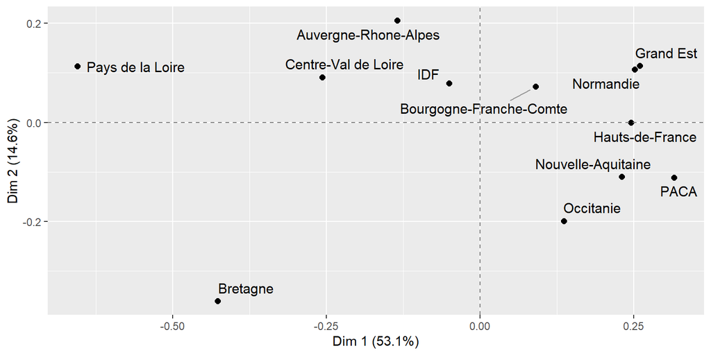

```r
ggplot2:::ggplot(data.frame(res.mfpca2$scores[, c(1:2)]), aes(x = X1, y = X2, label = rownames(res.mfpca2$scores))) +
  geom_point(color = "black", size = 2) +
  geom_text_repel(size = 4, box.padding = 0.4, point.padding = 0.3, segment.color = "gray60", segment.size  = 0.4, max.overlaps = Inf) +
  geom_hline(yintercept = 0, linetype = "dashed", color = "gray50") +
  geom_vline(xintercept = 0, linetype = "dashed", color = "gray50") +
  labs(x = paste0("Dim 1 (", round(propvar.mfpca2[1], 1), "%)"),
       y = paste0("Dim 2 (", round(propvar.mfpca2[2], 1), "%)"))
```

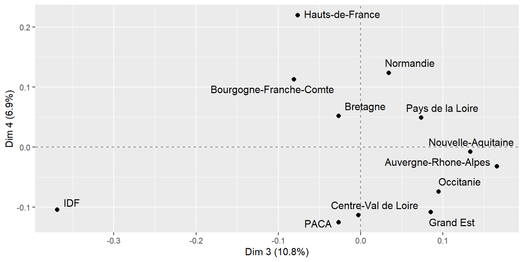

```r
ggplot2:::ggplot(data.frame(res.mfpca2$scores[, c(3:4)]), aes(x = X1, y = X2, label = rownames(res.mfpca2$scores))) +
  geom_point(color = "black", size = 2) +
  geom_text_repel(size = 4, box.padding = 0.4, point.padding = 0.3, segment.color = "gray60", segment.size  = 0.4, max.overlaps = Inf) +
  geom_hline(yintercept = 0, linetype = "dashed", color = "gray50") +
  geom_vline(xintercept = 0, linetype = "dashed", color = "gray50") +
  labs(x = paste0("Dim 3 (", round(propvar.mfpca2[3], 1), "%)"),
       y = paste0("Dim 4 (", round(propvar.mfpca2[4], 1), "%)"))
```

### 6.3.6 Interprétation

- Dimension 1 (53.1%) : Les régions ‘Pays de la Loire’ et ‘Bretagne’ se différencient des autres régions, notamment du fait des variables (‘log_AMC_EHPAD_C3G’), ‘log_AMC_ES_FQ’ (plus faibles valeurs) et ‘log_AMC_ville_macrolides’ (plus faibles valeurs).
- Dimension 2 (14.6%) : Les régions ‘Bretagne’ et ‘Auvergne-Rhône Alpes’ se différencient des autres régions, notamment du fait des variables ‘log_AMC_EHPAD_C3G’, ‘log_AMC_EHPAD_tmp_sulfa’, ‘log_AMC_ES_FQ’, ‘log_AMC_ES_totale’ et ‘log_AMC_ES_tot_except_FQ’.
- Dimension 3 (10.8%) : La région ‘IDF’ se différencie des autres régions, notamment du fait de la variable ‘log_AMC_ville_tetracyclines’ (valeurs élevées).

Pour aider

```r
(data.amc.mean <- aggregate(.~ region, data.amc, mean))
```

```
##                     region annee log_AMC_EHPAD_C3G log_AMC_EHPAD_FQ
## 1     Auvergne-Rhone-Alpes   7.5          1.684020         1.607624
## 2  Bourgogne-Franche-Comte   7.5          1.679591         1.546975
## 3                 Bretagne   7.5          1.700053         1.499471
## 4      Centre-Val de Loire   7.5          1.589441         1.525116
## 5                Grand Est   7.5          1.821858         1.645317
## 6          Hauts-de-France   7.5          1.765112         1.653664
## 7                      IDF   7.5          1.593794         1.505416
## 8                Normandie   7.5          1.791190         1.631534
## 9       Nouvelle-Aquitaine   7.5          1.902670         1.713086
## 10               Occitanie   7.5          1.837701         1.674562
## 11                    PACA   7.5          1.769696         1.775883
## 12        Pays de la Loire   7.5          1.400974         1.445413
##    log_AMC_EHPAD_aminoglycosides log_AMC_EHPAD_macrolides
## 1                     0.03640338                 1.725685
```

[output cut: 102 more lines]

# 7 Références

- Happ C, Scheipl F, Gabriel A-A, Greven S. (2019) A general framework for multivariate functional principal component analysis of amplitude and phase variation. Stat. ;8:e220. https://doi.org/10.1002/sta4.220
- Ramsay, James O., Silverman, Bernard W. (2005), Functional Data Analysis, 2nd ed., Springer, New York.